# Part II - (Ford GoBike System Data)

## by (Bouchoucha Mohammed)

## Investigation Overview

The aim of this investigation was to examine the user characteristics of GoBike over the period of February 2019 to identify factors that could potentially predict long-term usage. This information could then be used to provide better service to users.

## Dataset Overview

This document delves into a dataset that includes approximately 165,589 bike trips from February 2019, featuring 19 different variables. For this analysis, I am particularly interested in examining age, gender, user type, duration of usage, and time of usage. These variables are expected to provide us with sufficient data to make predictions and draw meaningful insights from the dataset.

## (Visualization 1)

- violin chart represent the gender types of our dataset with the age or each one

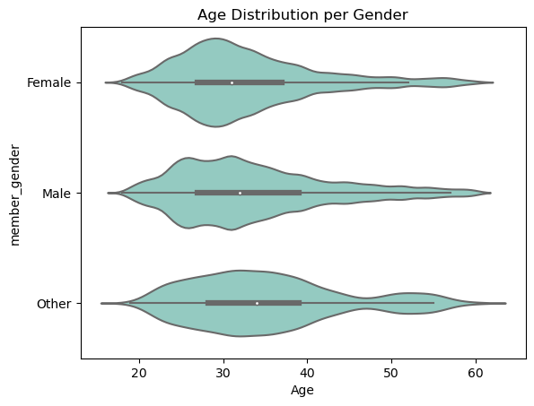

## (Visualization 2)

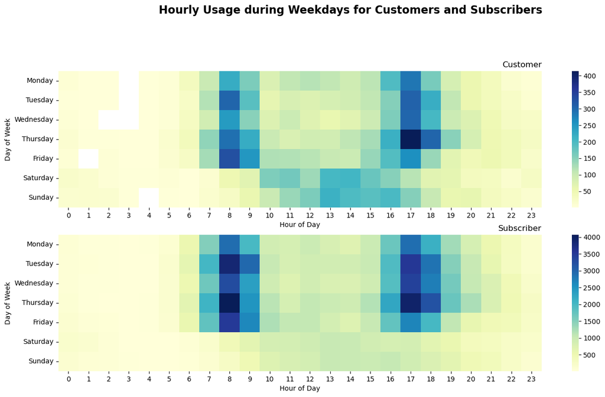

## (Visualization 3)

- The visualization below includes two bar graphs which depict the distribution of non-sharing and sharing trips across gender and user types.

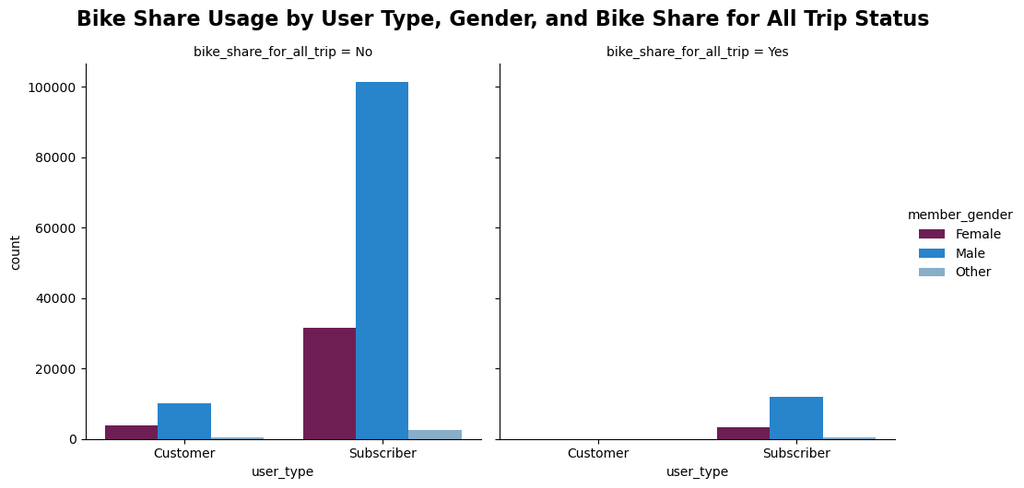